Converted from PDF `Zatzick-DownsizingInCrisis-2009-SMR.pdf` · 10 pages · anchors: page `#pN`, block `#pN-bK`

Page 1

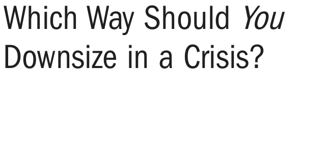

NOTE: figure/graphic rendered as an image from the PDF; its content is not machine-readable text. Caption (if any) follows as the next block.

**text found inside the figure**

Which Way Should You Downsize in a Crisis?

[figure not shown]

NOTE: figure/graphic rendered as an image from the PDF; its content is not machine-readable text. Caption (if any) follows as the next block.

**text found inside the figure**

FALL 2009 VOL. 51 NO. 1

#### REPRINT NUMBER 51118

## Christopher D. Zatzick, Mitchell L. Marks and Roderick D. Iverson

Page 2

FALL 2009 **MIT SLOAN MANAGEMENT REVIEW 79** COURTESY OF SOUTHWEST AIRLINES

THE GLOBAL economic downturn has forced many companies to make deep cuts to their work forces. Numerous retailers like Mervyn’s and Circuit City Stores Inc. closed locations, filed for bankruptcy or shut down altogether. Even companies like Yahoo!, Google, American Express and Motorola have had to cut their work forces.

The dramatic downturn in the economy left many organizations in a quandary. Several years ago, the major issue was winning the so-called war for talent: how to attract and retain the best and brightest. So companies implemented rigorous selection mechanisms, internal promotion ladders, extensive training and development, flexible work scheduling and group incentive schemes, all in hopes of developing a work force that would confer a sustainable competitive advantage. But then the recession turned that thinking upside down. Many organizations have been scrambling to figure out how best to restructure and cut costs *without* jeopardizing the valuable human capital that they had built.

To help such companies, we have developed a framework that integrates the seemingly paradoxical practices of talent management and downsizing. The framework looks at two important variables: the

Managers have been inundated with advice on the dos and don’ts of laying off employees. But the truth is that there is no ‘one size fits all’ approach to downsizing.

#### **BY CHRISTOPHER D. ZATZICK, MITCHELL L. MARKS AND RODERICK D. IVERSON**

## Which Way Should *You* Downsize in a Crisis?

**P E O P L E & S T R AT E G Y**

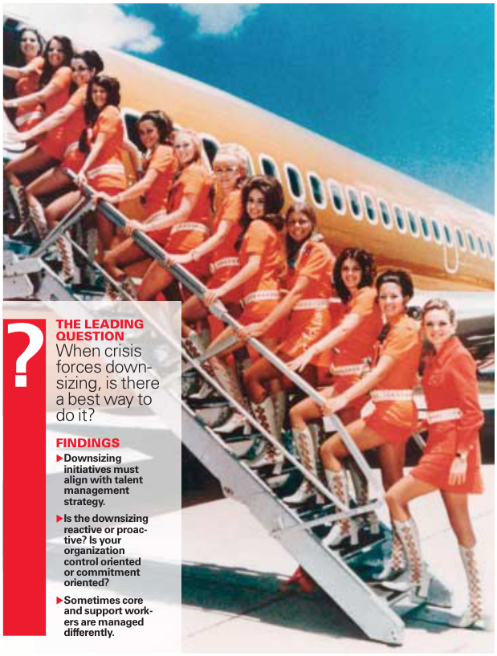

NOTE: figure/graphic rendered as an image from the PDF; its content is not machine-readable text. Caption (if any) follows as the next block.

**text found inside the figure**

**THE LEADING QUESTION** When crisis forces downsizing, is there a best way to do it?

**FINDINGS**

! **Downsizing initiatives must align with talent management strategy.**

! **Is the downsizing reactive or proactive? Is your organization control oriented or commitment oriented?**

! **Sometimes core and support workers are managed differently.**

**Since its launch 30 years ago, Southwest Airlines has pursued a no-involuntary-layoffs policy consistent with its talent culture. But it *has* found ways to reduce staffing when necessary.**

Page 3

**80 MIT SLOAN MANAGEMENT REVIEW** FALL 2009 SLOANREVIEW.MIT.EDU

**P E O P L E & S T R AT E G Y**

type of downsizing (reactive versus proactive) and the company’s approach to managing employees (control oriented versus commitment oriented). By first understanding an organization’s position with respect to those two dimensions, managers can devise an optimal strategy for downsizing.

**Two Important Dimensions** Of course, downsizing is not a new phenomenon. In fact, over the past two decades it has become a widespread tool for cutting costs and achieving operating efficiencies. Yet past research has shown that downsizing does not guarantee any performance returns.<sup>1</sup> Instead, layoffs often result in employees’ broken trust, increased burnout and decreased morale.<sup>2</sup> Hence, companies need to understand how to manage the process of work force reduction to attain its benefits while avoiding its ancillary costs.

There are two basic types of downsizing: reactive and proactive. The first type — reactive downsizing — is implemented in response to an economic or financial crisis, largely related to external changes in the marketplace (for example, a precipitous plunge in demand for a product line or service). This type of downsizing is more likely to be severe and can involve several rounds of layoffs. The primary strategic question that management asks is, “What do we need to survive now?” In contrast, the second type of downsizing — proactive — is implemented to enhance long-term competitive advantage by improving efficiencies, taking advantage of new technologies, changing the skills of the work force or restructuring the organization. This type of change might be characterized less as “downsizing” than “right sizing” or “resizing.”<sup>3</sup> Here, the primary strategic question that management asks is, “What do we need to thrive in the future?”

In addition, there are two basic approaches for managing employees: control oriented and commitment oriented. The first approach is typically used by organizations that compete with a strategy of operational excellence that focuses on offering low-cost products and services. The goal is to increase the efficiency of an organization, in part by reducing direct labor costs.<sup>4</sup> Some common aspects of a controloriented system include individual incentives such as piece-rate pay and sales commissions, centralized decision making, highly specialized jobs and electronic monitoring mechanisms such as video and Web-based

controls. In contrast, a commitment-oriented approach is focused on empowering employees to perform their jobs relatively independently using their discretion, according to the company’s goals.<sup>5</sup> Because such organizations view employees as critical to achieving competitive advantage, they tend to deploy HR practices that encourage the development of a highly skilled and committed work force that can outperform rival companies through increased innovation, flexibility and employee effort. Some of those practices include team-based work, enriched jobs that provide discretion and autonomy, internal promotion ladders, training and development opportunities, and group-based compensation such as profit sharing and gain sharing.

Although companies can have elements of both control- and commitment-oriented systems, the distinction will depend on the number, breadth and quality of the HR practices of each — as well as the corresponding employee perceptions of those practices. To avoid any confusion, management should be clear at the outset of any downsizing initiative as to whether it views employees fundamentally as a cost to be minimized or as an asset to be retained and developed. Either perspective can prove successful in achieving an organization’s goals, but major problems will occur when a company implements a downsizing initiative that is inconsistent.

**Four Quadrants** Those two dimensions — type of downsizing and approach to talent management — can be combined to form a two-by-two matrix consisting of four quadrants. (See “Four Major Types of Downsizing.”) Each quadrant represents a different strategy with a distinct philosophy, focus, and key HR and downsizing practices. Past research has shown that a company’s consideration for employee well-being is linked to its performance after a downsizing,<sup>6</sup> and other studies have identified the importance of various best practices, such as communicating with employees clearly and candidly.<sup>7</sup>(For a general list of those practices, see “Downsizing Best Practices,” p. 82.) Some experts have suggested that organizations should always deploy those best practices when downsizing, but we strongly contend that there is no “one size fits all” solution and that managers need to devise the approach that makes the best sense for their particular company, depending on its position in one of the matrix’s quadrants.

Page 4

SLOANREVIEW.MIT.EDU FALL 2009 **MIT SLOAN MANAGEMENT REVIEW 81**

**FOUR MAJOR TYPES OF DOWNSIZING** Managers should tailor any downsizing initiative according to the type of cutback (reactive versus proactive) and approach to managing employees (commitment oriented versus control oriented).

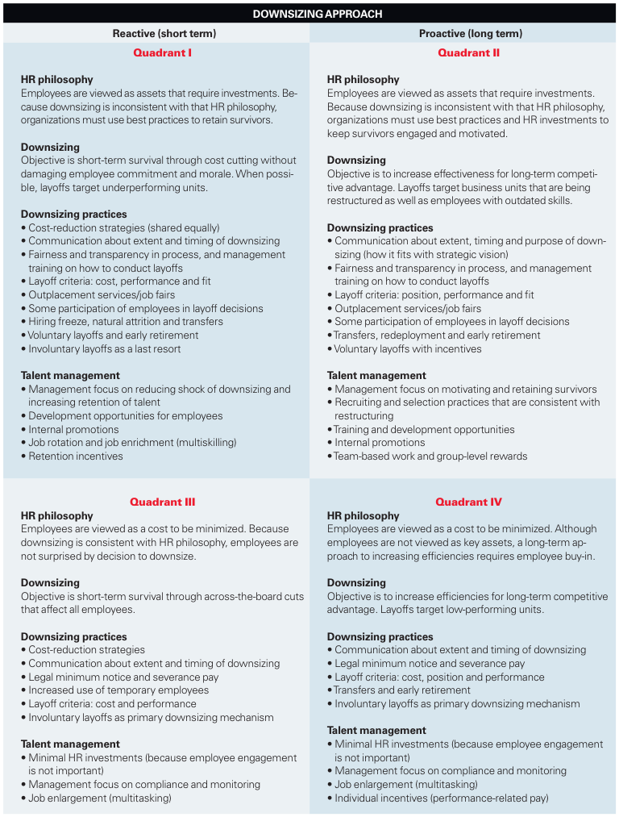

NOTE: figure/graphic rendered as an image from the PDF; its content is not machine-readable text. Caption (if any) follows as the next block.

**text found inside the figure**

**DOWNSIZING APPROACH**

**Reactive (short term) Proactive (long term)**

**Quadrant I**

**HR philosophy** Employees are viewed as assets that require investments. Because downsizing is inconsistent with that HR philosophy, organizations must use best practices to retain survivors.

**Downsizing** Objective is short-term survival through cost cutting without damaging employee commitment and morale. When possible, layoffs target underperforming units.

**Downsizing practices** • Cost-reduction strategies (shared equally) • Communication about extent and timing of downsizing • Fairness and transparency in process, and management training on how to conduct layoffs • Layoff criteria: cost, performance and fit • Outplacement services/job fairs • Some participation of employees in layoff decisions • Hiring freeze, natural attrition and transfers • Voluntary layoffs and early retirement • Involuntary layoffs as a last resort

**Talent management** • Management focus on reducing shock of downsizing and increasing retention of talent • Development opportunities for employees • Internal promotions • Job rotation and job enrichment (multiskilling) • Retention incentives

**Quadrant II**

**HR philosophy** Employees are viewed as assets that require investments. Because downsizing is inconsistent with that HR philosophy, organizations must use best practices and HR investments to keep survivors engaged and motivated.

**Downsizing** Objective is to increase effectiveness for long-term competitive advantage. Layoffs target business units that are being restructured as well as employees with outdated skills.

**Downsizing practices** • Communication about extent, timing and purpose of downsizing (how it fits with strategic vision) • Fairness and transparency in process, and management training on how to conduct layoffs • Layoff criteria: position, performance and fit • Outplacement services/job fairs • Some participation of employees in layoff decisions • Transfers, redeployment and early retirement • Voluntary layoffs with incentives

**Talent management** • Management focus on motivating and retaining survivors • Recruiting and selection practices that are consistent with restructuring • Training and development opportunities • Internal promotions • Team-based work and group-level rewards

**Quadrant III HR philosophy** Employees are viewed as a cost to be minimized. Because downsizing is consistent with HR philosophy, employees are not surprised by decision to downsize.

**Downsizing** Objective is short-term survival through across-the-board cuts that affect all employees.

**Downsizing practices** • Cost-reduction strategies • Communication about extent and timing of downsizing • Legal minimum notice and severance pay • Increased use of temporary employees • Layoff criteria: cost and performance • Involuntary layoffs as primary downsizing mechanism

**Talent management** • Minimal HR investments (because employee engagement is not important) • Management focus on compliance and monitoring • Job enlargement (multitasking)

**Quadrant IV HR philosophy** Employees are viewed as a cost to be minimized. Although employees are not viewed as key assets, a long-term approach to increasing efficiencies requires employee buy-in.

**Downsizing** Objective is to increase efficiencies for long-term competitive advantage. Layoffs target low-performing units.

**Downsizing practices** • Communication about extent and timing of downsizing • Legal minimum notice and severance pay • Layoff criteria: cost, position and performance • Transfers and early retirement • Involuntary layoffs as primary downsizing mechanism

**Talent management** • Minimal HR investments (because employee engagement is not important) • Management focus on compliance and monitoring • Job enlargement (multitasking) • Individual incentives (performance-related pay)

#### **TALENT-MANAGEMENT APPROACH**

#### **Commitment Oriented**

Page 5

**82 MIT SLOAN MANAGEMENT REVIEW** FALL 2009 SLOANREVIEW.MIT.EDU

**P E O P L E & S T R AT E G Y**

**Quadrant I: Reactive and Commitment Oriented** In this quadrant, companies downsize in reaction to an external shock, such as a recession. But because these organizations have a commitment-oriented approach to managing employees, they need to exercise great caution in order not to affect adversely their future ability to attract and retain valuable human capital. Following a layoff, for example, a number of the remaining employees sometimes quit,<sup>8</sup> and the cost of such turnover can reach up to $100,000 for professionals and managers.<sup>9</sup> And withdrawal can also be psychological — employees who continue to show up for work but are no longer engaged in their jobs. Hence, the challenge for organizations in this quadrant is to downsize while minimizing the loss of human capital.

Consider Xilinx Inc., a semiconductor manufacturer based in San Jose, California. Just prior to the 2001 dot-com bust, Xilinx had experienced a surge in growth, hiring more than 1,000 employees. When the technology bubble burst, though, the company had to slash costs immediately. But rather than laying off workers like many of its competitors had done, Xilinx deployed a host of alternatives, including temporary plant shutdowns, voluntary retirement and sabbatical leave. Moreover, managers consulted with employees before implementing pay cuts. Ultimately, Xilinx was able to weather the downturn without having to implement an involuntary layoff, thereby retaining a committed and motivated work force.<sup>10</sup>

**Quadrant II: Proactive and Commitment Oriented** On the surface, the decision to downsize, particularly when not mandated by a financial crisis, seems contradictory to the commitment-oriented approach, which views employees as a key asset. Consequently, managers must be careful to deploy a number of best practices so that the process makes sense to everyone. First, they should provide clear communications about the purpose, timing and extent of the downsizing. Much of the anxiety felt by workers can be alleviated early on by providing such information. Second, each step of the downsizing process must demonstrate why the change is necessary and affirm surviving employees’ value to the organization. This includes the use of many alternative downsizing practices, such as voluntary layoffs, early retirement and transfers, that are consistent

**DOWNSIZING BEST PRACTICES** The following best practices can help mitigate the negative effects of downsizing:

**Cut costs without reducing the work force.** The current economic downturn has seen organizations attempt to cut costs via pay freezes (or cuts), reduced 401k benefits, temporary plant or office closures, and mandatory vacation time.<sup>i</sup> These cost-reduction practices are generally viewed as an important attempt to avoid layoffs during a downturn.<sup>ii</sup> In a reactive downsizing, however, they are often just a first step and frequently are implemented in conjunction with layoffs at a later time.<sup>iii</sup>

**Reduce the work force without forced layoffs.** Organizations have a number of options for reducing the size of their work force, such as offering employees early retirement packages or instituting a hiring freeze so that natural attrition eventually results in lower head counts. Such approaches, however, may not be effective enough, and they can take time to work. In certain situations when an organization needs to downsize a particular department, it can use other mechanisms, such as internal transfers and redeployment of employees. Those practices allow organizations to identify positions that need to be cut as well as job opportunities for employees that need to be filled. Finally, voluntary layoffs offer a less harsh method of reducing staffing, as they allow employees to accept buyouts based on what fits their individual circumstances.

**Provide clear, candid and inclusive communications.** A successful downsizing requires companies to communicate effectively with employees.<sup>iv</sup> Such communications must be timely, explaining why the downsizing is needed and describing where the organization is headed. Moreover, to the extent possible, companies should address the likelihood of future layoffs. All levels of the corporate hierarchy (top executives, middle managers and front-line supervisors) should participate in delivering the communications in a variety of settings, including large group gatherings, regular team meetings, informal chats, newsletters and Web pages. The information conveyed must be consistent across the different sources and be personalized to each department and job. Companies should beware that the absence of effective communications will only allow the rumor mill to fill employees’ information gap, which will likely result in more uncertainty and heightened stress in the workplace. Finally, because managers often experience increased stress and burnout from having to communicate bad news to employees, an organization can provide them with the appropriate training to help minimize such effects.<sup>v</sup>

**Give employees a voice.** Before, during and after a downsizing, information must be allowed to flow in both directions, with employees given the opportunity to ask questions and air their concerns. They should also be permitted to express anger, frustration and even grief — emotions that are all natural during the transition.<sup>vi</sup> Consider the recent example of a small, family-owned car dealership that was forced to lay off 45 dedicated, longtime employees.<sup>vii</sup> The owners of the dealership described the process as extremely painful, with “45 deaths to grieve.” By providing an outlet for such losses, organizations can show compassion to those who have been laid off and give other employees the opportunity to let go and move on.<sup>viii</sup>

**Be fair and compassionate.** Because perceptions of fairness are critical to mitigating the negative effects of downsizing,<sup>ix</sup> companies must be careful about the way in which they implement any layoff. First, the selection of employees being shown the door is critical. Although some organizations must abide by certain union agreements, many companies do not have explicit policies regarding, for example, the importance of employee tenure. In such situations, managers might consider communicating the reasoning behind their decisions. Second, whenever possible, employees should be given sufficient notice of their layoffs to increase the chances of their finding new jobs without any break in employment. Part of that process should include outplacement services that the organization could provide by retaining an outside company. Third, the size of severance packages will be a major indicator of how a company views its workers and can affect (either positively or negatively) employee morale and motivation.

Page 6

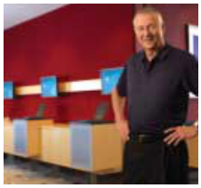

NOTE: figure/graphic rendered as an image from the PDF; its content is not machine-readable text. Caption (if any) follows as the next block.

FALL 2009 **MIT SLOAN MANAGEMENT REVIEW 83** COURTESY OF SAS

with a high-commitment approach.<sup>11</sup> Finally, managers should consider making HR investments (such as in skills training and job rotation) during and subsequent to the downsizing to retain the remaining workers and keep them engaged and productive. The surviving employees will view such investments as a trade-off, balancing the possibility of additional future layoffs with the opportunity to build their skills and gain valuable work experience.

Consider SAS Institute Inc., a statistical analysis software company based in Cary, North Carolina, that is well known for its extensive employee benefits and no-layoff policy. In 2006, SAS consolidated two marketing departments, which resulted in the elimination of 72 positions.<sup>12</sup> All affected employees were given the opportunity to apply for other positions in the organization or take generous severance and early-retirement packages. As such, the downsizing was conducted consistent with the organization’s commitment-oriented approach, which was essential for helping employees to understand the strategic decisions made.<sup>13</sup> Another example is Southwest Airlines Co., which has managed to maintain a no-layoff policy for over 30 years in the brutal, hypercompetitive airline industry. But that’s not to say that SWA never alters the size or composition of its work force. When the company cancels a route or closes a call center, for instance, management reduces staffing by giving employees the opportunity to transfer to other locations and by offering voluntary buyout packages with various amounts of cash, health care and travel benefits. Even in the current recession, SWA has continued to view involuntary layoffs as a last resort, relying instead on voluntary buyouts and transfers. (However, in contrast to prior downturns when forced layoffs were never raised as an option, this time around CEO Gary Kelly has not taken the possibility of involuntary layoffs off the table.<sup>14</sup>)

**Quadrant III: Reactive and Control Oriented** The recent economic climate has pushed some companies to the brink of collapse, forcing them to make dramatic cuts to their work forces. For organizations in this quadrant, employees are not viewed as key assets and can therefore be replaced easily in the short term, particularly with cheaper workers on a contingent basis. Hence, companies in this quadrant are likely to use extensive cost reductions combined with involuntary layoffs. They might, for

instance, provide just the minimum legal amount of notice and severance that the law requires (often 60 days’ or equivalent pay for mass layoffs). Further, they will often rely on simple incentive schemes such as sales commissions or piece-rate pay to compensate individuals. Finally, they might increase their use of monitoring mechanisms to ensure worker productivity during a transition period.

Take, for example, Circuit City Stores Inc. In 2007, the electronics retailer cut costs by replacing its highest-paid, top-performing sales employees with lower-paid, less-qualified new hires. But, according to critics, that decision resulted in poor customer service, an inexperienced work force and limited opportunities for employees in the organization.<sup>15</sup> Later, in response to the 2008 economic crisis, Circuit City closed numerous stores, laid off 10% of its work force and eventually filed for bankruptcy. Although the exact reasons for Circuit City’s downfall are complex, some have speculated that its earlier treatment of employees and mass layoffs were contributing factors.<sup>16</sup> At the very least, the retailer’s approach to downsizing left a lasting negative impression with the media and very likely damaged the morale and commitment of its work force.

But that’s not to say that a reactive and controloriented approach to downsizing necessarily leads to disaster. In fact, that approach is used regularly in the call-center industry. Workers at call centers typically receive limited training, are highly interchangeable, experience intense electronic monitoring and are motivated through individual incentives. Moreover, organizations that operate call centers tend to use involuntary layoffs as their primary downsizing mechanism, as has been the case with many telemarketing businesses such as TeleTech, CDG Management and Teleperformance. Even prominent corporations like eBay Inc. and Dell Inc. have abruptly closed Canadian call centers, displacing approximately 700 and 1,100 people, respectively.

**Quadrant IV: Proactive and Control Oriented** A company in this quadrant has identified threats or opportunities that require a change to the size of its work force, and because managers have adopted a more proactive, long-term approach to downsizing, they will rely on various best practices, including natural attrition, transfers and retirements. Even though

**An example of the “proactive and commitment-oriented” approach is SAS Institute (pictured, CEO Jim Goodnight), which has downsized by offering employees a menu of best-faith alternatives.**

Page 7

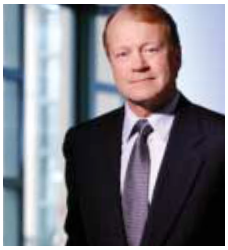

NOTE: figure/graphic rendered as an image from the PDF; its content is not machine-readable text. Caption (if any) follows as the next block.

**84 MIT SLOAN MANAGEMENT REVIEW** FALL 2009

**P E O P L E & S T R AT E G Y**

COURTESY OF CISCO SYSTEMS

employees are not considered to be key assets, the organization deploys those alternative strategies because it recognizes the potential costs of severance pay as well as the expenses associated with recruiting and training new hires. Furthermore, because downsizing is not implemented as a reaction to sudden changes in the economy, it typically is targeted to specific underperforming units or business processes.

Consider Wal-Mart Stores Inc., the massive retailer that is famous for its operational efficiencies and extensive control over all aspects of its business. Involuntary layoffs have not been commonplace at the retailer. When the company recently announced that it would downsize its apparel business, for instance, it transferred many of those workers to other locations. Because that decision was made proactively for internal reasons, Wal-Mart had the opportunity to manage the downsizing process with a more deliberate approach that helped avoid the severance costs of many involuntary layoffs. That said, Wal-Mart’s treatment of workers has often been criticized in the past, particularly with respect to employee benefits and attempts to form unions.<sup>17</sup>

**Learning From the Past** After the technology bubble burst in 2001, Cisco Systems Inc. laid off 8,500 employees, roughly 20% of its work force.<sup>18</sup> During that downsizing, the company also utilized many of the best practices needed to keep employees motivated and committed, but many felt that the company had been too quick to resort to layoffs. As a result, it suffered a decline in morale and a significant amount of voluntary turnover. Since then, CEO John Chambers vowed that Cisco would “build” rather than “acquire” talent, meaning that the company would focus on motivating and developing internal employees. In 2008, in response to the recent economic crisis, Cisco implemented layoffs only as a last resort after deploying a number of alternative measures. In other words, the company’s current response to the business downturn is more consistent with its commitmentoriented approach to talent management, whereas its actions in 2001 were somewhat contradictory.

After any downsizing, managers at a commitmentoriented company need to ask themselves: “Were we successful not only at cutting costs, but also in maintaining a committed and motivated work force?” The

decision to spend significant resources on employees, whether in the form of severance pay or continued investments in HR, will be difficult to justify when business is bad. Hence, the costs and benefits associated with each of those types of investments need to be evaluated. Take, for instance, Yahoo! Inc. Forced to implement layoffs because of the recession, Yahoo softened the blow with severance packages that covered up to two years of pay.<sup>19</sup> A company executive has argued that the generous packages were justified to retain other employees and keep them motivated during a difficult transition period. But was that costly expenditure truly worth it? The answer is more complex than it might first seem. Consider that the severance packages will likely limit the number of wrongful dismissal lawsuits filed by employees and minimize damage to the Yahoo brand.

Now contrast Yahoo’s approach with that of Republic Windows & Doors of Chicago. Last December, 250 workers at the company’s plant held a sit-in strike after being laid off without severance pay.<sup>20</sup>The ensuing negative publicity was a major embarrassment for Republic Windows and its creditor, Bank of America Corp., especially after BoA had earlier received a federal bailout of billions of dollars. Media coverage of the factory strike swayed public opinion against Republic Windows and BoA — some of the protesters carried signs stating, “You got bailed out, we got sold out” — and led to a quick settlement. For Republic Windows (and BoA), providing severance pay at the outset might well have been worth the expense in terms not only of avoiding potential legal issues with the laid-off workers but also with respect to minimizing any negative publicity from the downsizing.

Ultimately, severance pay and the implementation of other best practices should be evaluated as a costbenefit issue — does the expense (or investment) provide a good return? That assessment can be difficult, because it must involve various “soft” issues, such as the motivation of the remaining employees in a post-layoff environment. Undoubtedly, employees’ commitment to an organization will be affected greatly by how they and others were treated during a difficult period. Managers should be aware that feelings of “survivor guilt” can easily lead to a drop in productivity among those employees who have survived a layoff. Therefore, companies need to consider taking extra measures to motivate people during and after a layoff.

**In response to the 2008 economic crisis, Cisco Systems (pictured, CEO John Chambers) managed layoffs very differently than it had in 2001.**

Page 8

[figure not shown]

NOTE: figure/graphic rendered as an image from the PDF; its content is not machine-readable text. Caption (if any) follows as the next block.

SLOANREVIEW.MIT.EDU FALL 2009 **MIT SLOAN MANAGEMENT REVIEW 85**

THE NOTION THAT organizations should avoid downsizing at all costs is antiquated, but that doesn’t mean that companies should be free to downsize in any manner they desire. At the very least, they must ensure that their downsizing initiatives are aligned with their approach to talent management to send a consistent message to employees.<sup>21</sup> Consider Radical Entertainment Inc., a leader in the video gaming industry. Based in Vancouver, British Columbia, Radical has a culture and work force dedicated to developing cutting-edge products, with employees frequently working through the night to meet deadlines. In 2007, Radical doubled in size, recruiting about 100 new employees. Then, only one year later, the company announced a major downsizing of 100 layoffs.<sup>22</sup>That decision sent a confusing and conflicting message to employees, which could end up damaging Radical’s innovative culture as well as its ability to attract and retain top talent.

Of course, organizations do not typically have lavish budgets to implement a downsizing initiative — indeed, a scarcity of resources is why many companies must downsize in the first place — and, as such, they

may sometimes be forced to move from commitment to control approaches. In addition, some businesses have chosen to manage core and support workers differently,<sup>23</sup> so that various downsizing and talent management approaches are used within the same organization. Delta Air Lines Inc., for example, has offered voluntary exit incentives to all its workers *except* pilots and others in specialized positions.<sup>24</sup> That reflects the different value the company places on certain employees and its desire to prevent the loss of that human capital. Because of those and other complexities, managers should consider our framework as merely a first step toward developing a plan of action for any downsizing initiative. Even so, it provides a powerful tool for understanding various fundamental issues linking downsizing and talent management systems.

*Christopher D. Zatzick* *is an associate professor at the Faculty of Business Administration, Simon Fraser University;* *Mitchell L. Marks* *is an assistant professor at the College of Business, San Francisco State University; and* *Roderick D. Iverson* *is a professor at the Faculty of Business Administration, Simon Fraser University. Comment on this article or contact the authors at smrfeedback@mit.edu.*

Page 9

**86 MIT SLOAN MANAGEMENT REVIEW** FALL 2009 SLOANREVIEW.MIT.EDU

**P E O P L E & S T R AT E G Y**

#### **REFERENCES**

**1.** K.P. De Meuse, T.J. Bergmann, P.A. Vanderheiden and C.E. Roraff, “New Evidence Regarding Organizational Downsizing and a Firm’s Financial Performance: A Long- Term Analysis,” Journal of Managerial Issues 16, no. 2 (summer 2004): 155-177.

**2.** K.E. Mishra, G.M. Spreitzer and A.K. Mishra, “Preserving Employee Morale During Downsizing,” Sloan Management Review 39, no. 2 (winter 1998): 83-95; and A.K. Mishra, K.E. Mishra and G.M. Spreitzer, “Downsizing the Company Without Downsizing Morale,” MIT Sloan Management Review 50, no. 3 (spring 2009): 38-44.

**3.** M.L. Marks and K.P. De Meuse, “Resizing the Organization: Maximizing the Gain While Minimizing the Pain of Layoffs, Divestitures and Closings,” Organizational Dynamics 34, no. 1 (2005): 19-35.

**4.** R.L. Kane, “Downsizing and HRM Strategy: Is There a Relationship?” International Journal of Employment Studies 6, no. 2 (October 1998): 43-70.

**5.** Ibid.

**6.** C. Chadwick, L.W. Hunter and S.L. Walston, “Effects of Downsizing Practices on the Performance of Hospitals,” Strategic Management Journal 25, no. 5 (May 2004): 405-427.

**7.** J. Brockner, “Managing the Effects of Layoffs on Survivors,” California Management Review 34, no. 2 (winter 1992): 9-28; D.C. Feldman, “Better Practices in Managing Layoffs,” Human Resource Management 33, no. 2 (summer 1994): 239-260; and Mishra, “Preserving Employee Morale.”

**8.** C.O. Trevor and A.J. Nyberg, “Keeping Your Headcount When All About You Are Losing Theirs: Downsizing, Voluntary Turnover Rates and the Moderating Role of HR Practices,” Academy of Management Journal 51, no. 2 (April-May 2008): 259-276.

**9.** J. Brockner, “Why It’s So Hard to Be Fair,” Harvard Business Review 84 (March 2006): 122-129.

**10.** W.F. Cascio and P. Wynn, “Managing a Downsizing Process,” Human Resource Management 43, no. 4 (winter 2004): 159-163.

**11.** R.D. Iverson and C.D. Zatzick, “High-Commitment Work Practices and Downsizing Harshness in Australian Workplaces,” Industrial Relations 46, no. 3 (July 2007): 456-480.

**12.** A. Kirshnan, “Worker Shuffles at SAS Again,” July 12, 2006, www.newsobserver.com.

**13.** D.E. Bowen and C. Ostroff, “Understanding HRM- Firm Performance Linkages: The Role of the ‘Strength’ of the HRM System,” Academy of Management Review 29, no. 2 (2004): 203-221.

**14.** J. Dickler, “Employers: No Layoffs Here,” December 11, 2008, www.cnnmoney.com; “Southwest Offering Buyouts to Employees,” Associated Press, May 28, 2004, www.usatoday.com/travel/news/2004-05-28- swa-buyouts_x.htm; and M. Esterl, “Will Southwest Lose Some of the LUV?” April 17, 2009, http://blogs. wsj.com/middleseat/2009/04/17/will-southwest-losesome-of-the-luv/.

**15.** “Circuit City to Fire More Than 3,400 Workers,” Associated Press (2007); www.vancouversun.com.

**16.** S. Fallon, “Circuit City Layoffs May Have Contributed to Demise,” October 21, 2008, www.gizmo.com.

**17.** K. Griffiths, “Wal-Mart Crushes Union by Closing Store,” May 11, 2005, www.commondreams.org.

**18.** J.A. Chatman, C.A. O’Reilly and V. Chang, “Cisco Systems: Developing a Human Capital Strategy,” California Management Review 47, no. 2 (winter 2005): 137-167.

**19.** J. Vascellaro and S. Morrison, “Yahoo Revises Contentious Severance Plan,” Wall Street Journal, Dec. 11, 2008, sec. B, p. 1.

**20.** R. Shenoy, “Idled Workers Occupy Factory in Chicago,” Chicago Tribune, Dec. 6, 2008.

**21.** C.D. Zatzick and R. Iverson, “High-Involvement Management and Workforce Reduction: Competitive Advantage or Disadvantage?” Academy of Management Journal 49, no. 5 (2006): 999-1015; and Bowen, “Understanding HRM-Firm Performance.”

**22.** M. Andrews and F. Anderson, “Radical Layoffs at Radical Entertainment,” Aug. 14, 2008, www.vancouversun.com.

**23.** D.P. Lepak, M.S. Taylor, A.G. Tekleab, J.A. Marrone and D.J. Cohen, “An Examination of High-Investment Human Resource Systems for Core and Support Employees,” Human Resource Management 46, no. 2 (summer 2007): 223-246.

**24.** H. Weber, “Delta Offers Voluntary Severance” (2008); retrieved January 8, 2008, from http://news.cincinnati.com.

**i.** E.S. Barnes, “No-Layoff Policy,” July 2003, www.work force.com.

**ii.** M. Richtel, “More Companies Are Cutting Labor Costs Without Layoffs,” New York Times, Dec. 21, 2008, www. nytimes.com.

**iii.** F. Gandolfi, “Cost Reductions, Downsizing-Related Layoffs and HR Practices,” SAM Advanced Management Journal (summer 2008): 52-58.

**iv.** Brockner, “Managing Effects”; Mishra, “Preserving Employee Morale”; and Mishra, “Downsizing the Company.”

**v.** A. Molinsky and J. Margolis, “The Emotional Tightrope of Downsizing: Hidden Challenges for Leaders and Their Organizations,” Organizational Dynamics 35, no. 2 (May 2006): 145-159.

**vi.** W. Bridges, “Managing Transitions: Making the Most of Change” (Reading, Massachusetts: Addison Wesley, 1991).

**vii.** L. Hansen, “Auto Dealing Family Feels the Pinch,” Dec. 7, 2008, www.npr.org (audio).

**viii.** M.L. Marks, “A Framework for Facilitating Adaptation to Organizational Transition,” Journal of Organizational Change Management 20, no. 5 (2007): 721-739.

**ix.** J. Brockner, “The Effects of Work Layoffs on Survivors: Research, Theory and Practice,” vol. 10 in “Research in Organizational Behavior,” ed. B.M. Staw and L.L. Cummings (Greenwich, Connecticut: JAI Press, 1988), 213-255; and Brockner, “Managing the Effects.”

**Reprint 51118. Copyright ©** *Massachusetts Institute of Technology, 2009. All rights reserved.*

Page 10

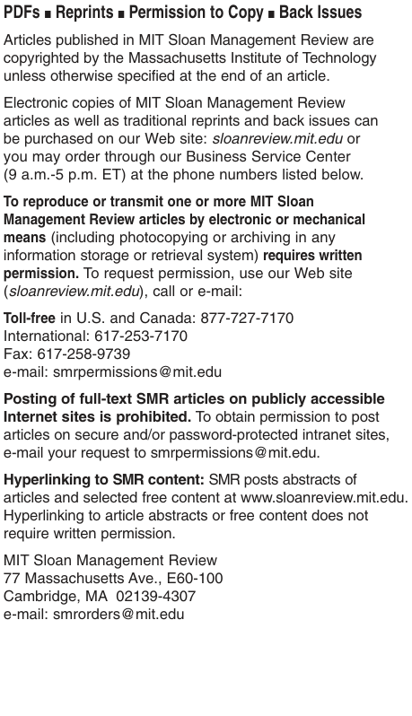

NOTE: figure/graphic rendered as an image from the PDF; its content is not machine-readable text. Caption (if any) follows as the next block.

**text found inside the figure**

**PDFs** ■ **Reprints** ■ **Permission to Copy** ■ **Back Issues**

Articles published in MIT Sloan Management Review are copyrighted by the Massachusetts Institute of Technology unless otherwise specified at the end of an article.

Electronic copies of MIT Sloan Management Review articles as well as traditional reprints and back issues can be purchased on our Web site: *sloanreview.mit.edu* or you may order through our Business Service Center (9 a.m.-5 p.m. ET) at the phone numbers listed below.

**To reproduce or transmit one or more MIT Sloan Management Review articles by electronic or mechanical means** (including photocopying or archiving in any information storage or retrieval system) **requires written permission.** To request permission, use our Web site (*sloanreview.mit.edu*), call or e-mail:

**Toll-free** in U.S. and Canada: 877-727-7170 International: 617-253-7170 Fax: 617-258-9739 e-mail: smrpermissions@mit.edu

**Posting of full-text SMR articles on publicly accessible Internet sites is prohibited.** To obtain permission to post articles on secure and/or password-protected intranet sites, e-mail your request to smrpermissions@mit.edu.

**Hyperlinking to SMR content:** SMR posts abstracts of articles and selected free content at www.sloanreview.mit.edu. Hyperlinking to article abstracts or free content does not require written permission.

MIT Sloan Management Review 77 Massachusetts Ave., E60-100 Cambridge, MA 02139-4307 e-mail: smrorders@mit.edu

[figure not shown]

NOTE: figure/graphic rendered as an image from the PDF; its content is not machine-readable text. Caption (if any) follows as the next block.